# 🎭 **Emotion Recognition From Speech**

# 😡 🤢 😨 😃 😮 😢 😐

## **Anger Disgust Fear Happiness Surprise Sadness Neutral**

## 🎧 **About the Dataset — Toronto Emotional Speech Set (TESS)**

The **Toronto Emotional Speech Set (TESS)** is a well-known emotional speech dataset developed to support research in **affective computing** and **speech emotion recognition (SER)**.

### 📄 **Dataset Structure**

- The dataset contains **2,800 audio recordings** in total.
- Recordings are based on **200 target words**, each embedded in the carrier phrase:  
  *"Say the word '**[target]**'"*.
- The words were spoken by **two female actors**:
  - One aged **26 years**
  - One aged **64 years**

Each phrase was spoken with **seven distinct emotional intonations**:

- 😠 Anger
- 🤢 Disgust
- 😨 Fear
- 😀 Happiness
- 😮 Pleasant Surprise
- 😢 Sadness
- 😐 Neutral

```python
# ------------------------------
#  System & Environment Setup
# ------------------------------
import os
import sys
import warnings
warnings.filterwarnings('ignore')

# ------------------------------
# Data Handling & Analysis
# ------------------------------
import numpy as np
import pandas as pd

# ------------------------------
#  Visualization
# ------------------------------
import seaborn as sns
import matplotlib.pyplot as plt

# ------------------------------
#  Audio Processing
# ------------------------------
import librosa
import librosa.display
from IPython.display import Audio  # for notebook playback

# ------------------------------
#  Machine Learning
# ------------------------------
from sklearn.preprocessing import StandardScaler, OneHotEncoder
from sklearn.model_selection import train_test_split
from sklearn.metrics import classification_report, confusion_matrix

# ------------------------------
#  Deep Learning
# ------------------------------
from keras.models import Sequential
from keras.optimizers import Adam
from keras.layers import SimpleRNN, LSTM, Dense, Dropout, BatchNormalization
import joblib
```

## **Prepare Data**

```python
# Path to the root dataset directory
tess_base_dir = './TESS Toronto emotional speech set data'

# Initialize containers
file_paths = []
file_emotions = []

# Define emotion mapping for known shorthand (if any appear like 'ps' -> surprise)
emotion_map = {
    'ps': 'surprise'
}

# Traverse subdirectories
for subfolder in os.listdir(tess_base_dir):
    subfolder_path = os.path.join(tess_base_dir, subfolder)

    if os.path.isdir(subfolder_path):
        for filename in os.listdir(subfolder_path):
            if filename.endswith('.wav'):
                # Example filename: YAF_back_angry.wav
                try:
                    emotion_code = filename.split('_')[2].lower().replace('.wav', '')
                    emotion = emotion_map.get(emotion_code, emotion_code)  # Map or use as-is
                    file_paths.append(os.path.join(subfolder_path, filename))
                    file_emotions.append(emotion)
                except IndexError:
                    print(f"Skipping file (unexpected format): {filename}")

# Convert to DataFrame
Tess_df = pd.DataFrame({
    'Emotions': file_emotions,
    'Path': file_paths
})

# 🧾 Preview a sample
display(Tess_df.sample(10))
```

|  | Emotions | Path |
| --- | --- | --- |
| 1290 | sad | ./TESS Toronto emotional speech set data\OAF_S... |
| 678 | happy | ./TESS Toronto emotional speech set data\OAF_h... |
| 251 | disgust | ./TESS Toronto emotional speech set data\OAF_d... |
| 758 | happy | ./TESS Toronto emotional speech set data\OAF_h... |
| 891 | neutral | ./TESS Toronto emotional speech set data\OAF_n... |
| 946 | neutral | ./TESS Toronto emotional speech set data\OAF_n... |
| 2627 | sad | ./TESS Toronto emotional speech set data\YAF_s... |
| 848 | neutral | ./TESS Toronto emotional speech set data\OAF_n... |
| 2187 | happy | ./TESS Toronto emotional speech set data\YAF_h... |
| 1260 | sad | ./TESS Toronto emotional speech set data\OAF_S... |

```python
emotion_list = np.array(sorted(Tess_df.Emotions.unique())).reshape(-1, 1)
print(emotion_list)
```

```
[['angry']
 ['disgust']
 ['fear']
 ['happy']
 ['neutral']
 ['sad']
 ['surprise']]
```

### **Distribution of Emotions**

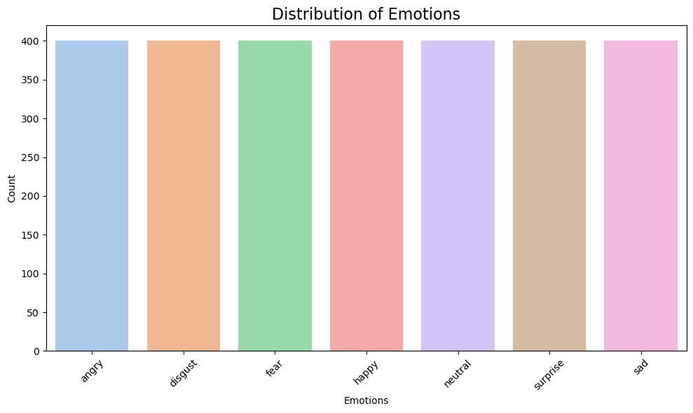

```python
# Count the occurrences of each emotion
emotion_counts = Tess_df['Emotions'].value_counts()


plt.figure(figsize=(10, 6))
sns.barplot(x=emotion_counts.index, y=emotion_counts.values, palette='pastel')
plt.title('Distribution of Emotions', size=16)
plt.xlabel('Emotions')
plt.ylabel('Count')
plt.xticks(rotation=45)
plt.tight_layout()
plt.show()
```

## 📊 **Waveplots and Spectrograms**

### 🎵 **Waveplots**

Waveplots show how the **amplitude (loudness)** of an audio signal varies over time.  
They help visualize the structure of speech or music — for example, where the audio gets louder, quieter, or silent.

- **X-axis**: Time (in seconds)
- **Y-axis**: Amplitude (signal intensity)

```python
def waveplot(data, sr, emotion):
    """
    Display a waveplot for the given audio data.

    Parameters:
    - data (ndarray): Audio time series.
    - sr (int): Sampling rate.
    - emotion (str): Emotion label.
    """
    plt.figure(figsize=(12, 4))
    librosa.display.waveshow(data, sr=sr, color='royalblue')
    plt.title(f'Waveform - Emotion: {emotion}', fontsize=14, fontweight='bold')
    plt.xlabel('Time (s)', fontsize=12)
    plt.ylabel('Amplitude', fontsize=12)
    plt.tight_layout()
    plt.show()
```

### 🔊 **Spectrograms**

Spectrograms provide a **time-frequency representation** of audio.  
They show how frequencies evolve over time and how much energy (volume) each frequency band carries at each moment.

- **X-axis**: Time
- **Y-axis**: Frequency (Hz or log scale)
- **Color Intensity**: Amplitude in decibels (dB)

This makes them highly effective for tasks like **emotion recognition**, **speech analysis**, and **sound classification**.

```python
def spectrogram(data, sr, emo):
    """
    Display a log-scaled spectrogram for the given audio data.

    Parameters:
    - data (ndarray): Audio time series.
    - sr (int): Sampling rate.
    - emo (str): Emotion label.
    """
    X = librosa.stft(data)
    Xdb = librosa.amplitude_to_db(np.abs(X))

    plt.figure(figsize=(14, 4))
    librosa.display.specshow(Xdb, sr=sr, x_axis='time', y_axis='log', cmap='magma')
    plt.colorbar(format='%+2.0f dB')
    plt.title(f'Spectrogram - Emotion: {emo}', fontsize=14, fontweight='bold')
    plt.xlabel('Time (s)')
    plt.ylabel('Frequency (log Hz)')
    plt.tight_layout()
    plt.show()
```

### 🎭 Emotion Samples

- 😠 **Anger**  
  Sharp, tense, or aggressive tone; often fast-paced and high-pitched.

[interactive chart not shown]

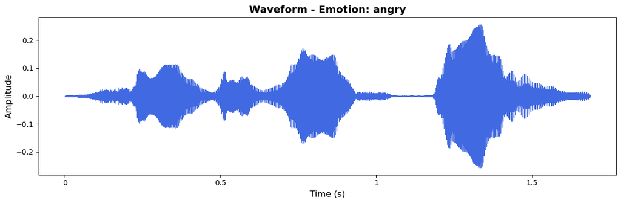

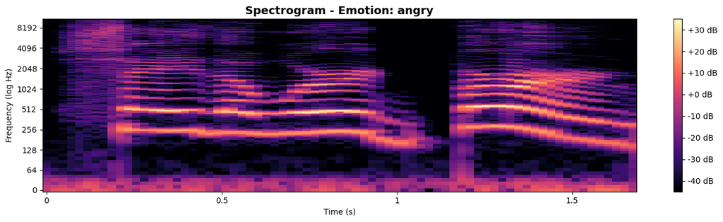

```python
# 🎯 Specify the emotion you want to visualize
emotion = 'angry'

# 🎧 Filter the DataFrame for the given emotion
path = np.array(Tess_df.Path[Tess_df.Emotions == emotion])[11]

# 📥 Load the audio data and sampling rate
audio_data, sampling_rate = librosa.load(path)

# ▶️ Audio playback
display(Audio(path))

# 📊 Waveform visualization
waveplot(audio_data, sampling_rate, emotion)

# 📈 Spectrogram visualization
spectrogram(audio_data, sampling_rate, emotion)
```

- 🤢 **Disgust**  
  Low-pitched, rough vocal expression; often slower with downward intonation.

[interactive chart not shown]

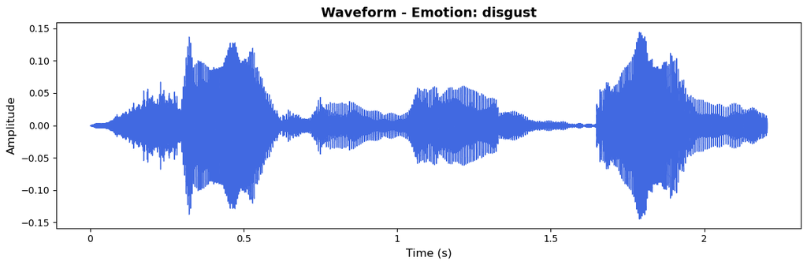

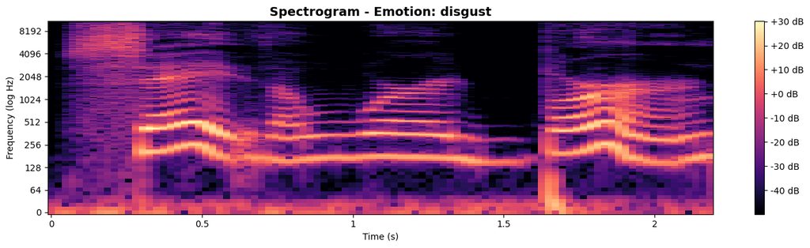

```python
# 🎯 Specify the emotion you want to visualize
emotion = 'disgust'

# 🎧 Filter the DataFrame for the given emotion
path = np.array(Tess_df.Path[Tess_df.Emotions == emotion])[11]

# 📥 Load the audio data and sampling rate
audio_data, sampling_rate = librosa.load(path)

# ▶️ Audio playback
display(Audio(path))

# 📊 Waveform visualization
waveplot(audio_data, sampling_rate, emotion)

# 📈 Spectrogram visualization
spectrogram(audio_data, sampling_rate, emotion)
```

- 😨 **Fear**  
  Shaky or tense delivery; may include a high pitch and irregular rhythm.

[interactive chart not shown]

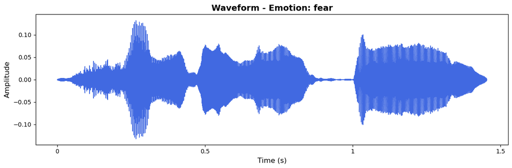

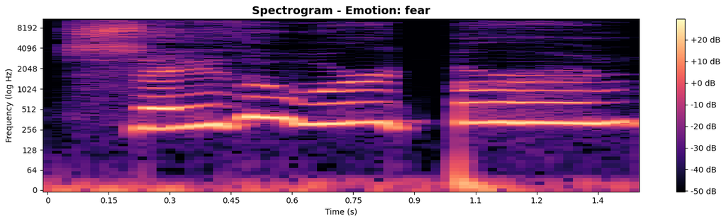

```python
# 🎯 Specify the emotion you want to visualize
emotion = 'fear'

# 🎧 Filter the DataFrame for the given emotion
path = np.array(Tess_df.Path[Tess_df.Emotions == emotion])[11]

# 📥 Load the audio data and sampling rate
audio_data, sampling_rate = librosa.load(path)

# ▶️ Audio playback
display(Audio(path))

# 📊 Waveform visualization
waveplot(audio_data, sampling_rate, emotion)

# 📈 Spectrogram visualization
spectrogram(audio_data, sampling_rate, emotion)
```

- 😀 **Happiness**  
  Energetic and bright tone; often faster tempo and higher pitch.

[interactive chart not shown]

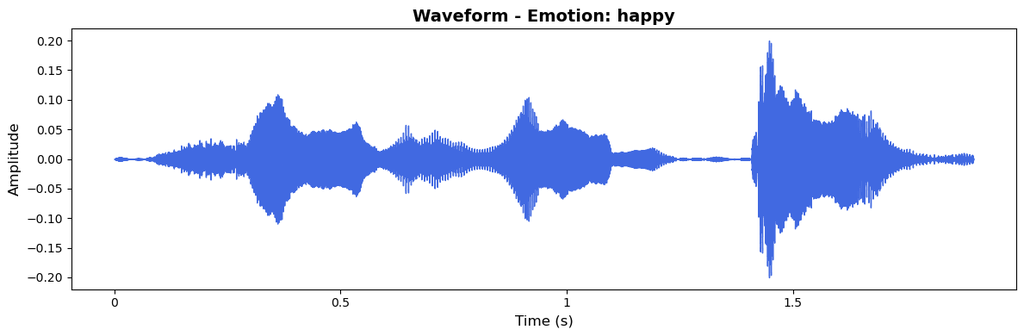

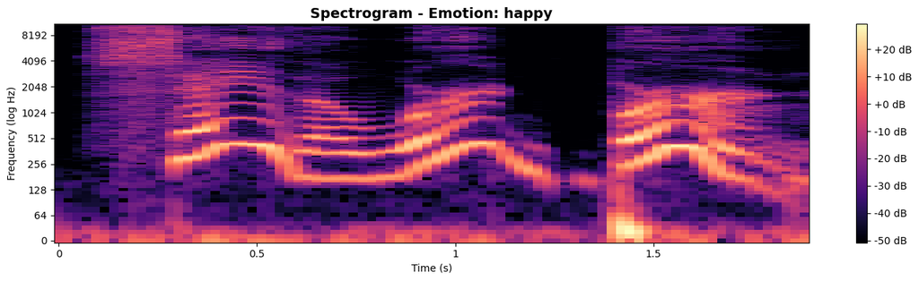

```python
# 🎯 Specify the emotion you want to visualize
emotion = 'happy'

# 🎧 Filter the DataFrame for the given emotion
path = np.array(Tess_df.Path[Tess_df.Emotions == emotion])[11]

# 📥 Load the audio data and sampling rate
audio_data, sampling_rate = librosa.load(path)

# ▶️ Audio playback
display(Audio(path))

# 📊 Waveform visualization
waveplot(audio_data, sampling_rate, emotion)

# 📈 Spectrogram visualization
spectrogram(audio_data, sampling_rate, emotion)
```

- 😐 **Neutral**  
  Calm, even pacing with no strong emotional cues.

[interactive chart not shown]

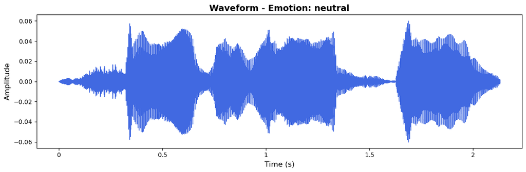

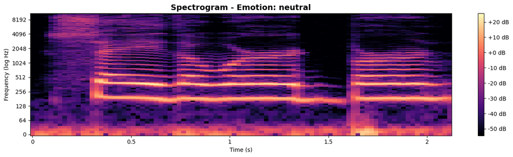

```python
# 🎯 Specify the emotion you want to visualize
emotion = 'neutral'

# 🎧 Filter the DataFrame for the given emotion
path = np.array(Tess_df.Path[Tess_df.Emotions == emotion])[11]

# 📥 Load the audio data and sampling rate
audio_data, sampling_rate = librosa.load(path)

# ▶️ Audio playback
display(Audio(path))

# 📊 Waveform visualization
waveplot(audio_data, sampling_rate, emotion)

# 📈 Spectrogram visualization
spectrogram(audio_data, sampling_rate, emotion)
```

- 😊 **Surprise**  
  Sudden pitch rise or energetic inflection; usually upbeat and brief.

[interactive chart not shown]

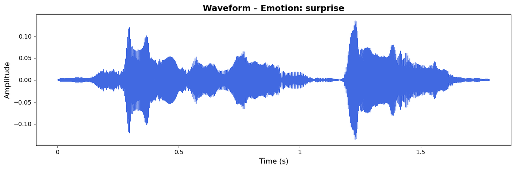

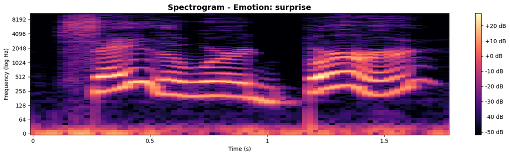

```python
# 🎯 Specify the emotion you want to visualize
emotion = 'surprise'

# 🎧 Filter the DataFrame for the given emotion
path = np.array(Tess_df.Path[Tess_df.Emotions == emotion])[11]

# 📥 Load the audio data and sampling rate
audio_data, sampling_rate = librosa.load(path)

# ▶️ Audio playback
display(Audio(path))

# 📊 Waveform visualization
waveplot(audio_data, sampling_rate, emotion)

# 📈 Spectrogram visualization
spectrogram(audio_data, sampling_rate, emotion)
```

- 😢 **Sadness**  
  Low volume, slower pace, and descending tone; often monotone or flat.

[interactive chart not shown]

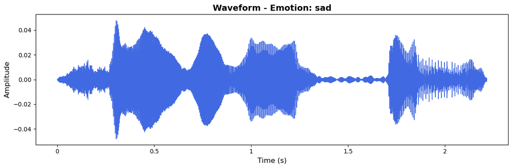

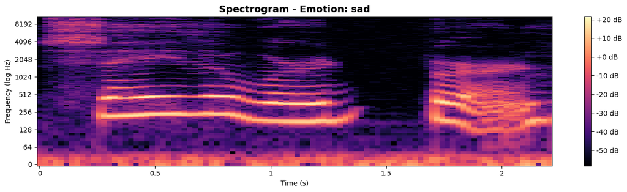

```python
# 🎯 Specify the emotion you want to visualize
emotion = 'sad'

# 🎧 Filter the DataFrame for the given emotion
path = np.array(Tess_df.Path[Tess_df.Emotions == emotion])[11]

# 📥 Load the audio data and sampling rate
audio_data, sampling_rate = librosa.load(path)

# ▶️ Audio playback
display(Audio(path))

# 📊 Waveform visualization
waveplot(audio_data, sampling_rate, emotion)

# 📈 Spectrogram visualization
spectrogram(audio_data, sampling_rate, emotion)
```

## 🎛️ **Data Augmentation for Audio Emotion Recognition**

Data augmentation involves generating new, slightly modified versions of existing samples to improve model generalization and reduce overfitting — especially useful when working with limited datasets.

### 🧠 Why Use Augmentation?

- Improves model robustness
- Reduces overfitting
- Mimics real-world distortions
- Creates data diversity from limited samples

### 🎧 **Common Audio Augmentation Techniques**

| Technique | Description |
| --- | --- |
| **Noise Injection** | Adds small random noise to simulate real-world background environments. |
| **Time Shifting** | Moves audio slightly forward/backward along the timeline. |
| **Pitch Shifting** | Changes the frequency/pitch without altering speed. |
| **Speed Tuning** | Slightly speeds up or slows down the audio. |
| **Volume Control** | Randomly increases or decreases amplitude levels. |
| **Time Stretching** | Alters duration without changing pitch. |

### ==========================

### 🎛️ Audio Augmentation Utilities

### ==========================

```python
def add_noise(data, noise_factor=0.035):
    """Add Gaussian noise to the audio signal."""
    noise_amp = noise_factor * np.random.uniform() * np.amax(data)
    return data + noise_amp * np.random.normal(size=data.shape[0])

def time_stretch(data, rate=0.8):
    """Stretch the audio in time (rate <1 slows down, >1 speeds up)."""
    return librosa.effects.time_stretch(data, rate=rate)

def time_shift(data, shift_max=5):
    """Randomly shift the audio forwards or backwards."""
    shift_range = int(np.random.uniform(low=-shift_max, high=shift_max) * 1000)
    return np.roll(data, shift_range)

def pitch_shift(data, sr, n_steps=0.7):
    """Change the pitch of the audio (n_steps <0 lowers pitch, >0 raises pitch)."""
    return librosa.effects.pitch_shift(data, sr=sr, n_steps=n_steps)
```

```python
# ==========================
# 🔉 Load Sample Audio
# ==========================
emotion = 'surprise'
path = Tess_df[Tess_df.Emotions == emotion].Path.values[11]  # pick second sample of the emotion
data, sr = librosa.load(path)

# Playback original
print("🔊 Original Audio:")
Audio(path)
```

```
🔊 Original Audio:
```

[interactive chart not shown]

```python
# ==========================
# 📈 Utility to Plot Waveforms
# ==========================

def plot_waveform(data, sr, title, color='steelblue'):
    plt.figure(figsize=(14, 4))
    librosa.display.waveshow(data, sr=sr, color=color)
    plt.title(title, fontsize=14, fontweight='bold')
    plt.xlabel("Time (s)")
    plt.ylabel("Amplitude")
    plt.tight_layout()
    plt.show()
```

### **Applying `Noise` on Sample Data**

```
🔊 Noisy Audio:
```

[interactive chart not shown]

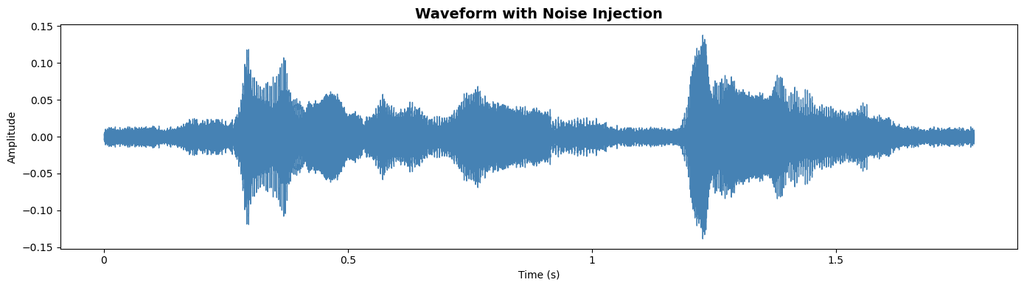

```
🔊 Stretched Audio:
```

[interactive chart not shown]

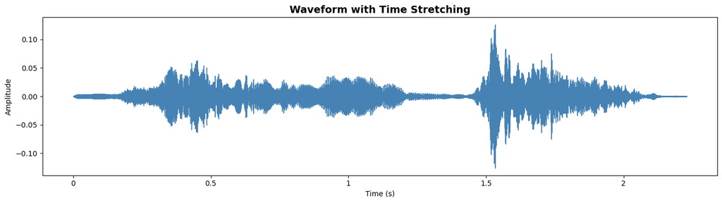

```
🔊 Shifted Audio:
```

[interactive chart not shown]

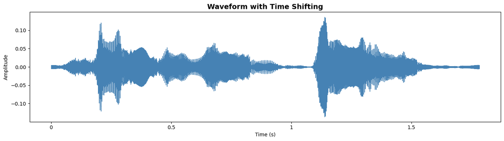

```
🔊 Pitch-Shifted Audio:
```

[interactive chart not shown]

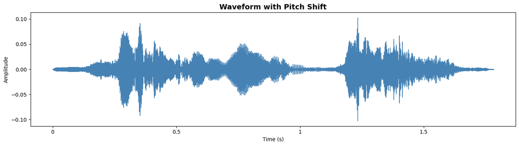

```python
# ==========================
# 🔄 Apply & Visualize Augmentations
# ==========================

# 🎧 Noise Injection
noisy = add_noise(data)
print("🔊 Noisy Audio:")
display(Audio(noisy, rate=sr))
plot_waveform(noisy, sr, "Waveform with Noise Injection")

# ⏱️ Time Stretch
stretched = time_stretch(data, rate=0.8)
print("🔊 Stretched Audio:")
display(Audio(stretched, rate=sr))
plot_waveform(stretched, sr, "Waveform with Time Stretching")

# ⏪ Time Shift
shifted = time_shift(data)
print("🔊 Shifted Audio:")
display(Audio(shifted, rate=sr))
plot_waveform(shifted, sr, "Waveform with Time Shifting")

# 🎵 Pitch Shift
pitched = pitch_shift(data, sr, n_steps=0.7)
print("🔊 Pitch-Shifted Audio:")
display(Audio(pitched, rate=sr))
plot_waveform(pitched, sr, "Waveform with Pitch Shift")
```

## 🧠 **Feature Extraction**

### 🎯 Features Used:

- **Zero Crossing Rate**  
  Measures how frequently the audio signal crosses the zero amplitude axis. It helps in detecting noisiness or percussive elements.
- **Chroma Short-Time Fourier Transform (Chroma STFT)**  
  Represents the 12 different pitch classes (semitones of the musical octave), making it useful for capturing harmonic content.
- **MFCC (Mel-Frequency Cepstral Coefficients)**  
  Captures the timbral texture of audio based on how humans perceive sound frequencies. One of the most critical features for speech and music analysis.
- **RMS (Root Mean Square) Energy**  
  Provides a measure of the power (or loudness) of the signal over time. Helps capture energy fluctuations.

These features will be extracted using **Librosa**, a Python library specialized for music and audio analysis, and then used to train deep learning models for emotion classification.

```python
def extract_features(data, sample_rate):
    """
    Extract essential audio features for Speech Emotion Recognition.

    Features included:
    1. Zero Crossing Rate (ZCR)
    2. Chroma STFT (12 chroma features)
    3. MFCC (13 coefficients)
    4. RMS Energy

    Parameters:
    - data (ndarray): Audio time series.
    - sample_rate (int): Sampling rate of the audio.

    Returns:
    - ndarray: A 1D array of combined extracted audio features.
    """
    result = []

    # 1. Zero Crossing Rate
    # Measures how often the signal crosses zero amplitude (useful for percussive sounds)
    zcr = librosa.feature.zero_crossing_rate(y=data)
    result.append(np.mean(zcr))

    # 2. Chroma STFT
    # Captures harmonic content across 12 pitch classes (like a musical octave)
    stft = np.abs(librosa.stft(data))
    chroma = librosa.feature.chroma_stft(S=stft, sr=sample_rate)
    result.extend(np.mean(chroma, axis=1))  # Add 12 chroma features

    # 3. MFCC (Mel-frequency cepstral coefficients)
    # Extract 13 MFCCs (standard for speech/audio tasks)
    mfcc = librosa.feature.mfcc(y=data, sr=sample_rate, n_mfcc=13)
    result.extend(np.mean(mfcc, axis=1))  # Add 13 MFCC features

    # 4. RMS Energy
    # Represents signal energy over time (related to loudness)
    rms = librosa.feature.rms(y=data)
    result.append(np.mean(rms))

    return np.array(result)  # Total features = 1 (ZCR) + 12 (Chroma) + 13 (MFCC) + 1 (RMS) = 27 features
```

```python
def get_features(path):
    """
    Load audio data and extract features with and without augmentations.

    Augmentations:
    1. Noise Injection
    2. Time Stretching
    3. Time Shifting
    4. Pitch Shifting

    Parameters:
    - path (str): Path to the audio file.

    Returns:
    - ndarray: Combined features (original + augmented versions).
    """
    # Load audio with a fixed duration and offset to remove silence
    data, sample_rate = librosa.load(path, duration=2.5, offset=0.6)

    # Initialize with original audio features
    result = [extract_features(data, sample_rate)]

    # ➕ 1. Noise Injection
    noisy = add_noise(data)
    result.append(extract_features(noisy, sample_rate))

    # ➕ 2. Time Stretching (avoid extreme stretch for stability)
    stretched = time_stretch(data, rate=0.9)
    result.append(extract_features(stretched, sample_rate))

    # ➕ 3. Time Shifting
    shifted = time_shift(data)
    result.append(extract_features(shifted, sample_rate))

    # ➕ 4. Pitch Shifting
    pitched = pitch_shift(data, sample_rate)
    result.append(extract_features(pitched, sample_rate))

    # Combine all feature vectors into a single matrix
    return np.vstack(result)
```

## 📦 Feature Extraction & Dataset Creation

In this step, we extract features from **each audio file** in the TESS dataset using the previously defined `get_features()` function, which includes both the **original signal** and **multiple augmented versions** (noise, stretch, pitch, shift, etc.).

Each augmented version is treated as a separate training sample, but all inherit the same emotion label as the original file. This increases dataset diversity and improves model generalization.

### 🔄 Process Overview

- **Loop through** every file in the dataset along with its corresponding emotion label.
- **Apply augmentation + feature extraction** via `get_features(path)`.
- **Store** extracted feature vectors in `X` and their associated emotion labels in `Y`.

### 📊 Create and Save Dataset

- A new **Pandas DataFrame** is constructed with extracted features.
- The corresponding emotion label is stored in a `labels` column.
- The final dataset is saved to a CSV file (`features.csv`) for future model training.

### 💡 Why Save as CSV?

Storing features in a CSV allows:

- Faster training (no real-time feature extraction)
- Easier reuse across multiple models or notebooks
- Portable dataset format

```python
#  Extract features from all files
X, Y = [], []

for path, emotion in zip(Tess_df.Path, Tess_df.Emotions):
    features = get_features(path)
    for f in features:
        X.append(f)
        Y.append(emotion)  # Same label for all augmentations of same file


# Create DataFrame
Features = pd.DataFrame(X)
Features['labels'] = Y

#  Save to CSV
Features.to_csv('features.csv', index=False)

#  Preview the result
Features.head()
```

|  | 0 | 1 | 2 | 3 | 4 | 5 | 6 | 7 | 8 | 9 | ... | 18 | 19 | 20 | 21 | 22 | 23 | 24 | 25 | 26 | labels |
| --- | --- | --- | --- | --- | --- | --- | --- | --- | --- | --- | --- | --- | --- | --- | --- | --- | --- | --- | --- | --- | --- |
| 0 | 0.054342 | 0.538993 | 0.596808 | 0.396304 | 0.364695 | 0.441099 | 0.413557 | 0.373404 | 0.568095 | 0.573010 | ... | 13.788046 | -19.953243 | -7.025360 | -5.187742 | 1.833246 | -1.251280 | 1.479892 | 2.302237 | 0.042422 | angry |
| 1 | 0.256919 | 0.739981 | 0.730825 | 0.561175 | 0.567954 | 0.670792 | 0.562489 | 0.499118 | 0.691988 | 0.650148 | ... | 3.747479 | -5.055089 | -6.089222 | -2.144392 | 1.505629 | 2.677672 | -0.556730 | -1.096106 | 0.044959 | angry |
| 2 | 0.066178 | 0.587914 | 0.644441 | 0.453818 | 0.393858 | 0.450042 | 0.428998 | 0.346855 | 0.593103 | 0.649939 | ... | 12.835048 | -21.699118 | -8.160928 | -6.939551 | 1.038952 | -0.797239 | 1.700956 | 2.175554 | 0.032035 | angry |
| 3 | 0.052996 | 0.551786 | 0.599161 | 0.395301 | 0.354750 | 0.424583 | 0.412519 | 0.363460 | 0.552836 | 0.584619 | ... | 13.661558 | -19.757517 | -7.158725 | -5.664441 | 1.454081 | -1.968398 | 1.010208 | 1.734280 | 0.042911 | angry |
| 4 | 0.064358 | 0.548217 | 0.647106 | 0.422424 | 0.335561 | 0.398601 | 0.413497 | 0.346496 | 0.567810 | 0.604020 | ... | 9.295422 | -23.711420 | -6.682881 | -6.393191 | 2.952513 | -0.475778 | 2.147178 | 2.336817 | 0.033923 | angry |

5 rows × 28 columns

```python
# Output the lengths of the feature list (X) and the label list (Y),
# as well as the shape of the data path to verify dataset consistency
len(X), len(Y), Tess_df.Path.shape  # len(X): number of extracted features, len(Y): number of emotion labels, data_path.Path.shape: total number of audio files
```

```
(14000, 14000, (2800,))
```

- **We have performed data augmentation, extracted features from each audio file, and saved the results.**

## **Data Preparation**

We have extracted the data, and now we need to normalize it and split it into training and testing sets.

```python
# Extract feature values from the DataFrame, excluding the last column (labels)
X = Features.iloc[:, :-1].values  # X contains all rows and all columns except the last one

# Extract the labels from the 'labels' column of the DataFrame
Y = Features['labels'].values  # Y contains the emotion labels corresponding to the features
```

### **Since this is a multiclass classification problem, we need to apply one-hot encoding to the labels (Y)**

```python
encoder = OneHotEncoder()  # Initialize the OneHotEncoder

# Fit the encoder to the labels and transform them into a one-hot encoded format
Y = encoder.fit_transform(np.array(Y).reshape(-1, 1)).toarray()  # Reshape Y for compatibility and convert to a dense array
```

```python
joblib.dump(encoder, 'encoder.joblib')
```

[output not shown]

### **Split the dataset into training and testing sets**

```python
# x_train and y_train will be used for training the model, while x_test and y_test will be used for evaluation
x_train, x_test, y_train, y_test = train_test_split(X, Y, random_state=0, shuffle=True)

# Display the shapes of the training and testing sets to verify the split
x_train.shape, y_train.shape, x_test.shape, y_test.shape
```

```
((10500, 27), (10500, 7), (3500, 27), (3500, 7))
```

```python
print("Train size:", len(x_train))
print("Test size:", len(x_test))
```

```
Train size: 10500
Test size: 3500
```

```python
#  Convert your raw training data into a DataFrame (before scaling)
df_before = pd.DataFrame(x_train, columns=[f'Feature_{i}' for i in range(x_train.shape[1])])
```

### **Scale the data using sklearn's StandardScaler to standardize features by removing the mean and scaling to unit variance**

```python
scaler = StandardScaler()  # Initialize the StandardScaler

# Fit the scaler to the training data and transform it
x_train = scaler.fit_transform(x_train)  # Apply scaling to the training data

# Transform the testing data using the fitted scaler (without fitting again)
x_test = scaler.transform(x_test)  # Apply the same scaling to the test data

# ✅ Save the fitted scaler to a file
joblib.dump(scaler, 'scaler.joblib')

# Display the shapes of the scaled training and testing sets to verify
print(x_train.shape, y_train.shape, x_test.shape, y_test.shape)
```

```
(10500, 27) (10500, 7) (3500, 27) (3500, 7)
```

```python
df_after = pd.DataFrame(x_train, columns=[f'Feature_{i}' for i in range(x_train.shape[1])])
```

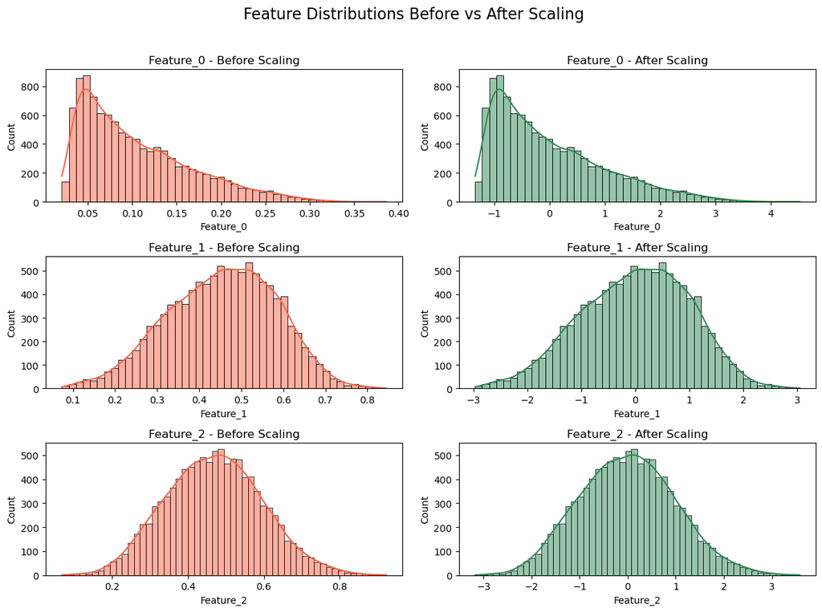

```python
features_to_plot = ['Feature_0', 'Feature_1', 'Feature_2']

fig, axes = plt.subplots(len(features_to_plot), 2, figsize=(12, 9))
fig.suptitle(" Feature Distributions Before vs After Scaling", fontsize=16)

for i, feat in enumerate(features_to_plot):
    sns.histplot(df_before[feat], kde=True, ax=axes[i, 0], color='tomato')
    axes[i, 0].set_title(f"{feat} - Before Scaling")

    sns.histplot(df_after[feat], kde=True, ax=axes[i, 1], color='seagreen')
    axes[i, 1].set_title(f"{feat} - After Scaling")

plt.tight_layout(rect=[0, 0, 1, 0.96])
plt.show()
```

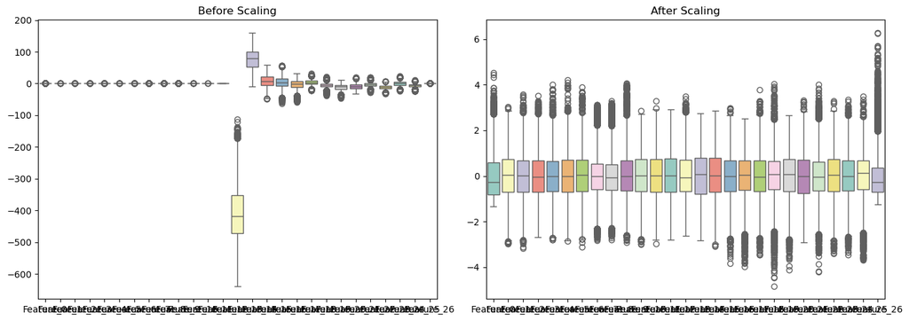

```python
plt.figure(figsize=(14, 5))

# Boxplot before scaling
plt.subplot(1, 2, 1)
sns.boxplot(data=df_before, palette='Set3')
plt.title('Before Scaling')

# Boxplot after scaling
plt.subplot(1, 2, 2)
sns.boxplot(data=df_after, palette='Set3')
plt.title('After Scaling')

plt.tight_layout()
plt.show()
```

### **Expand the dimensions of the training and testing data to make them compatible with the model's input requirements**

```python
x_train = np.expand_dims(x_train, axis=2)  # Add a new dimension to x_train at the specified axis (2)
x_test = np.expand_dims(x_test, axis=2)    # Add a new dimension to x_test at the specified axis (2)

# Display the shapes of the modified training and testing sets to verify the dimension changes
x_train.shape, y_train.shape, x_test.shape, y_test.shape
```

```
((10500, 27, 1), (10500, 7), (3500, 27, 1), (3500, 7))
```

## **Applying Deep Learning Models**

### **Use RNN**

```python
# Define a function to create the RNN model
def create_rnn_model(input_shape, num_classes):
    # Initialize a sequential model
    model = Sequential()



    #  First RNN layer: 128 units
    # input_shape specifies the shape of the input data
    # return_sequences=True allows the next layer to receive the full sequence of outputs

    model.add(SimpleRNN(128, input_shape=input_shape, return_sequences=True))
    model.add(BatchNormalization()) # Normalize the outputs of the previous layer
    model.add(Dropout(0.3))# Apply dropout to prevent overfitting



    #  Second RNN layer: 64 units, returns full sequences
    model.add(SimpleRNN(64, return_sequences=True))
    model.add(BatchNormalization())  # Normalize outputs
    model.add(Dropout(0.3))          # Apply dropout



    # Third RNN layer: 32 units, returns final output
    model.add(SimpleRNN(32))
    model.add(BatchNormalization())   # Normalize outputs



    # Output layer with 'num_classes' units for multi-class classification
    # Uses softmax activation function to output probabilities for each class
    model.add(Dense(num_classes, activation='softmax'))


    return model
```

```python
# Set the input shape based on the training data
input_shape = (27, 1)  # Each input sample has 155 time steps and 1 feature
num_classes = 7         # Number of emotion classes to predict

# Create the RNN model using the defined function
model = create_rnn_model(input_shape, num_classes)

# Compile the model with the Adam optimizer and categorical cross-entropy loss
# Metrics are set to track accuracy during training
model.compile(optimizer='adam', loss='categorical_crossentropy', metrics=['accuracy'])

# Display a summary of the model's architecture
model.summary()
```

```
Model: "sequential"
```

```
┏━━━━━━━━━━━━━━━━━━━━━━━━━━━━━━━━━┳━━━━━━━━━━━━━━━━━━━━━━━━┳━━━━━━━━━━━━━━━┓
┃ Layer (type)                    ┃ Output Shape           ┃       Param # ┃
┡━━━━━━━━━━━━━━━━━━━━━━━━━━━━━━━━━╇━━━━━━━━━━━━━━━━━━━━━━━━╇━━━━━━━━━━━━━━━┩
│ simple_rnn (SimpleRNN)          │ (None, 27, 128)        │        16,640 │
├─────────────────────────────────┼────────────────────────┼───────────────┤
│ batch_normalization             │ (None, 27, 128)        │           512 │
│ (BatchNormalization)            │                        │               │
├─────────────────────────────────┼────────────────────────┼───────────────┤
│ dropout (Dropout)               │ (None, 27, 128)        │             0 │
├─────────────────────────────────┼────────────────────────┼───────────────┤
│ simple_rnn_1 (SimpleRNN)        │ (None, 27, 64)         │        12,352 │
├─────────────────────────────────┼────────────────────────┼───────────────┤
│ batch_normalization_1           │ (None, 27, 64)         │           256 │
│ (BatchNormalization)            │                        │               │
├─────────────────────────────────┼────────────────────────┼───────────────┤
│ dropout_1 (Dropout)             │ (None, 27, 64)         │             0 │
├─────────────────────────────────┼────────────────────────┼───────────────┤
│ simple_rnn_2 (SimpleRNN)        │ (None, 32)             │         3,104 │
├─────────────────────────────────┼────────────────────────┼───────────────┤
│ batch_normalization_2           │ (None, 32)             │           128 │
│ (BatchNormalization)            │                        │               │
├─────────────────────────────────┼────────────────────────┼───────────────┤
│ dense (Dense)                   │ (None, 7)              │           231 │
└─────────────────────────────────┴────────────────────────┴───────────────┘
```

```
 Total params: 33,223 (129.78 KB)
```

```
 Trainable params: 32,775 (128.03 KB)
```

```
 Non-trainable params: 448 (1.75 KB)
```

### **Train this model**

```python
# Fit the model on the training data

'''
- 'x_train' is the input data for training, and 'y_train' is the corresponding labels
-  'epochs' specifies the number of complete passes through the training dataset
-  'batch_size' defines the number of samples processed before the model is updated
-  'validation_data' is a tuple (x_test, y_test) used to evaluate the model's performance on unseen data after each epoch
'''

history = model.fit(x_train, y_train, epochs=50, batch_size=32, validation_data=(x_test, y_test))
```

```
329/329 ━━━━━━━━━━━━━━━━━━━━ 12s 19ms/step - accuracy: 0.5896 - loss: 1.1319 - val_accuracy: 0.8909 - val_loss: 0.3290
329/329 ━━━━━━━━━━━━━━━━━━━━ 5s 16ms/step - accuracy: 0.8592 - loss: 0.4267 - val_accuracy: 0.8543 - val_loss: 0.4159
329/329 ━━━━━━━━━━━━━━━━━━━━ 5s 16ms/step - accuracy: 0.8974 - loss: 0.3202 - val_accuracy: 0.9363 - val_loss: 0.1953
329/329 ━━━━━━━━━━━━━━━━━━━━ 6s 17ms/step - accuracy: 0.9178 - loss: 0.2402 - val_accuracy: 0.9203 - val_loss: 0.2333
329/329 ━━━━━━━━━━━━━━━━━━━━ 5s 16ms/step - accuracy: 0.9209 - loss: 0.2356 - val_accuracy: 0.9526 - val_loss: 0.1369
329/329 ━━━━━━━━━━━━━━━━━━━━ 5s 16ms/step - accuracy: 0.9385 - loss: 0.1935 - val_accuracy: 0.9357 - val_loss: 0.1979
329/329 ━━━━━━━━━━━━━━━━━━━━ 5s 16ms/step - accuracy: 0.9360 - loss: 0.1948 - val_accuracy: 0.9403 - val_loss: 0.1925
329/329 ━━━━━━━━━━━━━━━━━━━━ 5s 17ms/step - accuracy: 0.9251 - loss: 0.2372 - val_accuracy: 0.9597 - val_loss: 0.1164
329/329 ━━━━━━━━━━━━━━━━━━━━ 5s 16ms/step - accuracy: 0.9514 - loss: 0.1436 - val_accuracy: 0.9454 - val_loss: 0.1684
329/329 ━━━━━━━━━━━━━━━━━━━━ 5s 17ms/step - accuracy: 0.9431 - loss: 0.1759 - val_accuracy: 0.9529 - val_loss: 0.1545
329/329 ━━━━━━━━━━━━━━━━━━━━ 5s 16ms/step - accuracy: 0.9501 - loss: 0.1456 - val_accuracy: 0.9440 - val_loss: 0.1797
329/329 ━━━━━━━━━━━━━━━━━━━━ 5s 16ms/step - accuracy: 0.9524 - loss: 0.1381 - val_accuracy: 0.9514 - val_loss: 0.1489
329/329 ━━━━━━━━━━━━━━━━━━━━ 5s 17ms/step - accuracy: 0.9463 - loss: 0.1569 - val_accuracy: 0.9671 - val_loss: 0.0960
329/329 ━━━━━━━━━━━━━━━━━━━━ 6s 17ms/step - accuracy: 0.9560 - loss: 0.1341 - val_accuracy: 0.9357 - val_loss: 0.2057
329/329 ━━━━━━━━━━━━━━━━━━━━ 5s 16ms/step - accuracy: 0.9499 - loss: 0.1552 - val_accuracy: 0.9486 - val_loss: 0.1791
329/329 ━━━━━━━━━━━━━━━━━━━━ 5s 16ms/step - accuracy: 0.9542 - loss: 0.1399 - val_accuracy: 0.9500 - val_loss: 0.1594
329/329 ━━━━━━━━━━━━━━━━━━━━ 6s 17ms/step - accuracy: 0.9577 - loss: 0.1263 - val_accuracy: 0.9440 - val_loss: 0.1738
329/329 ━━━━━━━━━━━━━━━━━━━━ 5s 16ms/step - accuracy: 0.9027 - loss: 0.3133 - val_accuracy: 0.9691 - val_loss: 0.0875
329/329 ━━━━━━━━━━━━━━━━━━━━ 5s 16ms/step - accuracy: 0.9666 - loss: 0.1049 - val_accuracy: 0.9491 - val_loss: 0.1662
329/329 ━━━━━━━━━━━━━━━━━━━━ 5s 16ms/step - accuracy: 0.9605 - loss: 0.1253 - val_accuracy: 0.9480 - val_loss: 0.1658
329/329 ━━━━━━━━━━━━━━━━━━━━ 5s 16ms/step - accuracy: 0.9598 - loss: 0.1290 - val_accuracy: 0.9714 - val_loss: 0.0959
329/329 ━━━━━━━━━━━━━━━━━━━━ 5s 16ms/step - accuracy: 0.9689 - loss: 0.0960 - val_accuracy: 0.9711 - val_loss: 0.0873
329/329 ━━━━━━━━━━━━━━━━━━━━ 5s 16ms/step - accuracy: 0.9629 - loss: 0.1181 - val_accuracy: 0.9697 - val_loss: 0.0866
329/329 ━━━━━━━━━━━━━━━━━━━━ 5s 16ms/step - accuracy: 0.9673 - loss: 0.0997 - val_accuracy: 0.9597 - val_loss: 0.1202
329/329 ━━━━━━━━━━━━━━━━━━━━ 6s 18ms/step - accuracy: 0.9676 - loss: 0.1065 - val_accuracy: 0.9677 - val_loss: 0.1015
329/329 ━━━━━━━━━━━━━━━━━━━━ 5s 17ms/step - accuracy: 0.9708 - loss: 0.0971 - val_accuracy: 0.9554 - val_loss: 0.1409
329/329 ━━━━━━━━━━━━━━━━━━━━ 5s 16ms/step - accuracy: 0.9716 - loss: 0.0865 - val_accuracy: 0.9634 - val_loss: 0.1084
329/329 ━━━━━━━━━━━━━━━━━━━━ 5s 16ms/step - accuracy: 0.9778 - loss: 0.0704 - val_accuracy: 0.9629 - val_loss: 0.1178
329/329 ━━━━━━━━━━━━━━━━━━━━ 5s 16ms/step - accuracy: 0.9569 - loss: 0.1339 - val_accuracy: 0.9743 - val_loss: 0.0852
329/329 ━━━━━━━━━━━━━━━━━━━━ 5s 16ms/step - accuracy: 0.9620 - loss: 0.1155 - val_accuracy: 0.9706 - val_loss: 0.0873
329/329 ━━━━━━━━━━━━━━━━━━━━ 5s 16ms/step - accuracy: 0.9719 - loss: 0.0908 - val_accuracy: 0.9643 - val_loss: 0.1113
329/329 ━━━━━━━━━━━━━━━━━━━━ 6s 17ms/step - accuracy: 0.9668 - loss: 0.1091 - val_accuracy: 0.9703 - val_loss: 0.0974
329/329 ━━━━━━━━━━━━━━━━━━━━ 5s 16ms/step - accuracy: 0.9752 - loss: 0.0751 - val_accuracy: 0.9717 - val_loss: 0.0951
329/329 ━━━━━━━━━━━━━━━━━━━━ 5s 17ms/step - accuracy: 0.9706 - loss: 0.0874 - val_accuracy: 0.9637 - val_loss: 0.1142
329/329 ━━━━━━━━━━━━━━━━━━━━ 5s 17ms/step - accuracy: 0.9738 - loss: 0.0852 - val_accuracy: 0.9637 - val_loss: 0.1096
329/329 ━━━━━━━━━━━━━━━━━━━━ 5s 16ms/step - accuracy: 0.9676 - loss: 0.1056 - val_accuracy: 0.9534 - val_loss: 0.1672
329/329 ━━━━━━━━━━━━━━━━━━━━ 5s 16ms/step - accuracy: 0.8958 - loss: 0.3369 - val_accuracy: 0.9629 - val_loss: 0.1147
329/329 ━━━━━━━━━━━━━━━━━━━━ 5s 16ms/step - accuracy: 0.9728 - loss: 0.0896 - val_accuracy: 0.9746 - val_loss: 0.0818
329/329 ━━━━━━━━━━━━━━━━━━━━ 6s 17ms/step - accuracy: 0.9707 - loss: 0.0868 - val_accuracy: 0.9669 - val_loss: 0.1252
329/329 ━━━━━━━━━━━━━━━━━━━━ 6s 18ms/step - accuracy: 0.9392 - loss: 0.1993 - val_accuracy: 0.9600 - val_loss: 0.1400
329/329 ━━━━━━━━━━━━━━━━━━━━ 5s 16ms/step - accuracy: 0.9656 - loss: 0.1100 - val_accuracy: 0.9646 - val_loss: 0.1172
329/329 ━━━━━━━━━━━━━━━━━━━━ 6s 17ms/step - accuracy: 0.9732 - loss: 0.0882 - val_accuracy: 0.9774 - val_loss: 0.0854
329/329 ━━━━━━━━━━━━━━━━━━━━ 6s 17ms/step - accuracy: 0.9783 - loss: 0.0748 - val_accuracy: 0.9769 - val_loss: 0.0703
329/329 ━━━━━━━━━━━━━━━━━━━━ 5s 16ms/step - accuracy: 0.9750 - loss: 0.0817 - val_accuracy: 0.9474 - val_loss: 0.1695
329/329 ━━━━━━━━━━━━━━━━━━━━ 6s 17ms/step - accuracy: 0.9655 - loss: 0.1152 - val_accuracy: 0.9811 - val_loss: 0.0715
329/329 ━━━━━━━━━━━━━━━━━━━━ 6s 17ms/step - accuracy: 0.9734 - loss: 0.0834 - val_accuracy: 0.9731 - val_loss: 0.0898
329/329 ━━━━━━━━━━━━━━━━━━━━ 6s 17ms/step - accuracy: 0.9738 - loss: 0.0822 - val_accuracy: 0.9749 - val_loss: 0.0832
329/329 ━━━━━━━━━━━━━━━━━━━━ 5s 16ms/step - accuracy: 0.9501 - loss: 0.1660 - val_accuracy: 0.9600 - val_loss: 0.1309
329/329 ━━━━━━━━━━━━━━━━━━━━ 5s 16ms/step - accuracy: 0.9726 - loss: 0.0887 - val_accuracy: 0.9769 - val_loss: 0.0810
329/329 ━━━━━━━━━━━━━━━━━━━━ 6s 17ms/step - accuracy: 0.9800 - loss: 0.0661 - val_accuracy: 0.9674 - val_loss: 0.1181
```

### **Evaluate the SimpleRNN Performance**

```
110/110 ━━━━━━━━━━━━━━━━━━━━ 1s 5ms/step - accuracy: 0.9656 - loss: 0.1216
Accuracy of our model on test data: 96.74285650253296 %
```

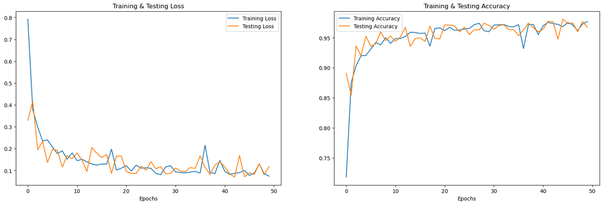

```python
# Evaluate the model on the test data and print the accuracy
# model.evaluate returns a list where the second element is the accuracy
print("Accuracy of our model on test data:", model.evaluate(x_test, y_test)[1] * 100, "%")

# Create a list of epochs for x-axis representation
epochs = [i for i in range(50)]  # Assuming you trained for 50 epochs

# Create subplots for loss and accuracy
fig, ax = plt.subplots(1, 2)  # 1 row, 2 columns of plots

# Extract training and validation metrics from the history object
train_acc = history.history['accuracy']       # Training accuracy for each epoch
train_loss = history.history['loss']           # Training loss for each epoch
test_acc = history.history['val_accuracy']     # Validation accuracy for each epoch
test_loss = history.history['val_loss']        # Validation loss for each epoch

# Set the size of the figure
fig.set_size_inches(20, 6)

# Plot the training and testing loss
ax[0].plot(epochs, train_loss, label='Training Loss')  # Plot training loss
ax[0].plot(epochs, test_loss, label='Testing Loss')    # Plot testing loss
ax[0].set_title('Training & Testing Loss')              # Title for the loss plot
ax[0].legend()                                         # Add a legend to the plot
ax[0].set_xlabel("Epochs")                            # Label for x-axis

# Plot the training and testing accuracy
ax[1].plot(epochs, train_acc, label='Training Accuracy')  # Plot training accuracy
ax[1].plot(epochs, test_acc, label='Testing Accuracy')    # Plot testing accuracy
ax[1].set_title('Training & Testing Accuracy')             # Title for the accuracy plot
ax[1].legend()                                           # Add a legend to the plot
ax[1].set_xlabel("Epochs")                              # Label for x-axis

# Display the plots
plt.show()
```

### **Use LSTM model**

```python
def create_lstm_model(input_shape, num_classes):
    model = Sequential()

    # First LSTM layer
    model.add(LSTM(128, input_shape=input_shape, return_sequences=True))
    model.add(BatchNormalization())
    model.add(Dropout(0.3))

    # Second LSTM layer
    model.add(LSTM(64, return_sequences=False))
    model.add(BatchNormalization())
    model.add(Dropout(0.3))

    # Dense layer for learning combinations of extracted features
    model.add(Dense(64, activation='relu'))
    model.add(Dropout(0.3))

    # Output layer
    model.add(Dense(num_classes, activation='softmax'))

    return model
```

```python
# Set input shape and number of classes
input_shape = (27, 1)  # Corresponding to x_train shape
num_classes = 7         # Corresponding to y_train shape

# Create the LSTM model
LSTM_model = create_lstm_model(input_shape, num_classes)

# Compile the model
LSTM_model.compile(optimizer='adam', loss='categorical_crossentropy', metrics=['accuracy'])

# Summary of the model
LSTM_model.summary()
```

```
Model: "sequential_3"
```

```
┏━━━━━━━━━━━━━━━━━━━━━━━━━━━━━━━━━┳━━━━━━━━━━━━━━━━━━━━━━━━┳━━━━━━━━━━━━━━━┓
┃ Layer (type)                    ┃ Output Shape           ┃       Param # ┃
┡━━━━━━━━━━━━━━━━━━━━━━━━━━━━━━━━━╇━━━━━━━━━━━━━━━━━━━━━━━━╇━━━━━━━━━━━━━━━┩
│ lstm_5 (LSTM)                   │ (None, 27, 128)        │        66,560 │
├─────────────────────────────────┼────────────────────────┼───────────────┤
│ batch_normalization_8           │ (None, 27, 128)        │           512 │
│ (BatchNormalization)            │                        │               │
├─────────────────────────────────┼────────────────────────┼───────────────┤
│ dropout_7 (Dropout)             │ (None, 27, 128)        │             0 │
├─────────────────────────────────┼────────────────────────┼───────────────┤
│ lstm_6 (LSTM)                   │ (None, 64)             │        49,408 │
├─────────────────────────────────┼────────────────────────┼───────────────┤
│ batch_normalization_9           │ (None, 64)             │           256 │
│ (BatchNormalization)            │                        │               │
├─────────────────────────────────┼────────────────────────┼───────────────┤
│ dropout_8 (Dropout)             │ (None, 64)             │             0 │
├─────────────────────────────────┼────────────────────────┼───────────────┤
│ dense_4 (Dense)                 │ (None, 64)             │         4,160 │
├─────────────────────────────────┼────────────────────────┼───────────────┤
│ dropout_9 (Dropout)             │ (None, 64)             │             0 │
├─────────────────────────────────┼────────────────────────┼───────────────┤
│ dense_5 (Dense)                 │ (None, 7)              │           455 │
└─────────────────────────────────┴────────────────────────┴───────────────┘
```

```
 Total params: 121,351 (474.03 KB)
```

```
 Trainable params: 120,967 (472.53 KB)
```

```
 Non-trainable params: 384 (1.50 KB)
```

```python
from keras.callbacks import EarlyStopping, ModelCheckpoint
```

```python
#  EarlyStopping: Stop training if val_loss does not improve for 5 consecutive epochs
early_stop = EarlyStopping(monitor='val_loss', patience=5, restore_best_weights=True, verbose=1)
#   ModelCheckpoint: Save the best model based on validation accuracy
checkpoint = ModelCheckpoint('best_lstm_model.keras', monitor='val_accuracy', save_best_only=True, verbose=1)
```

```python
# Fit the moLSTM_modeldel on the training data
history = LSTM_model.fit(
    x_train, y_train,
    epochs=50,
    batch_size=32,
    validation_data=(x_test, y_test),
    callbacks=[early_stop, checkpoint]  # Add callbacks here
)
```

```
327/329 ━━━━━━━━━━━━━━━━━━━━ 0s 25ms/step - accuracy: 0.4345 - loss: 1.5231
Epoch 1: val_accuracy improved from -inf to 0.57429, saving model to best_lstm_model.keras
329/329 ━━━━━━━━━━━━━━━━━━━━ 15s 30ms/step - accuracy: 0.4354 - loss: 1.5205 - val_accuracy: 0.5743 - val_loss: 1.1744
328/329 ━━━━━━━━━━━━━━━━━━━━ 0s 25ms/step - accuracy: 0.6734 - loss: 0.8450
Epoch 2: val_accuracy improved from 0.57429 to 0.75600, saving model to best_lstm_model.keras
329/329 ━━━━━━━━━━━━━━━━━━━━ 9s 28ms/step - accuracy: 0.6735 - loss: 0.8447 - val_accuracy: 0.7560 - val_loss: 0.6603
327/329 ━━━━━━━━━━━━━━━━━━━━ 0s 26ms/step - accuracy: 0.7767 - loss: 0.6086
Epoch 3: val_accuracy improved from 0.75600 to 0.87714, saving model to best_lstm_model.keras
329/329 ━━━━━━━━━━━━━━━━━━━━ 10s 30ms/step - accuracy: 0.7768 - loss: 0.6083 - val_accuracy: 0.8771 - val_loss: 0.3466
329/329 ━━━━━━━━━━━━━━━━━━━━ 0s 26ms/step - accuracy: 0.8501 - loss: 0.4332
Epoch 4: val_accuracy improved from 0.87714 to 0.90514, saving model to best_lstm_model.keras
329/329 ━━━━━━━━━━━━━━━━━━━━ 10s 30ms/step - accuracy: 0.8502 - loss: 0.4331 - val_accuracy: 0.9051 - val_loss: 0.2862
327/329 ━━━━━━━━━━━━━━━━━━━━ 0s 26ms/step - accuracy: 0.8686 - loss: 0.3879
Epoch 5: val_accuracy improved from 0.90514 to 0.92143, saving model to best_lstm_model.keras
329/329 ━━━━━━━━━━━━━━━━━━━━ 10s 30ms/step - accuracy: 0.8687 - loss: 0.3876 - val_accuracy: 0.9214 - val_loss: 0.2242
329/329 ━━━━━━━━━━━━━━━━━━━━ 0s 26ms/step - accuracy: 0.8999 - loss: 0.2839
Epoch 6: val_accuracy did not improve from 0.92143
329/329 ━━━━━━━━━━━━━━━━━━━━ 10s 29ms/step - accuracy: 0.8999 - loss: 0.2839 - val_accuracy: 0.9080 - val_loss: 0.2732
327/329 ━━━━━━━━━━━━━━━━━━━━ 0s 25ms/step - accuracy: 0.9089 - loss: 0.2729
Epoch 7: val_accuracy improved from 0.92143 to 0.93971, saving model to best_lstm_model.keras
329/329 ━━━━━━━━━━━━━━━━━━━━ 10s 29ms/step - accuracy: 0.9089 - loss: 0.2727 - val_accuracy: 0.9397 - val_loss: 0.1738
329/329 ━━━━━━━━━━━━━━━━━━━━ 0s 25ms/step - accuracy: 0.9207 - loss: 0.2407
Epoch 8: val_accuracy did not improve from 0.93971
329/329 ━━━━━━━━━━━━━━━━━━━━ 9s 29ms/step - accuracy: 0.9207 - loss: 0.2407 - val_accuracy: 0.9357 - val_loss: 0.1895
329/329 ━━━━━━━━━━━━━━━━━━━━ 0s 26ms/step - accuracy: 0.9200 - loss: 0.2201
Epoch 9: val_accuracy improved from 0.93971 to 0.94029, saving model to best_lstm_model.keras
329/329 ━━━━━━━━━━━━━━━━━━━━ 10s 30ms/step - accuracy: 0.9200 - loss: 0.2201 - val_accuracy: 0.9403 - val_loss: 0.1667
327/329 ━━━━━━━━━━━━━━━━━━━━ 0s 26ms/step - accuracy: 0.9288 - loss: 0.2189
Epoch 10: val_accuracy did not improve from 0.94029
329/329 ━━━━━━━━━━━━━━━━━━━━ 10s 29ms/step - accuracy: 0.9289 - loss: 0.2188 - val_accuracy: 0.9351 - val_loss: 0.1962
329/329 ━━━━━━━━━━━━━━━━━━━━ 0s 27ms/step - accuracy: 0.9251 - loss: 0.2246
Epoch 11: val_accuracy improved from 0.94029 to 0.95114, saving model to best_lstm_model.keras
329/329 ━━━━━━━━━━━━━━━━━━━━ 11s 31ms/step - accuracy: 0.9251 - loss: 0.2246 - val_accuracy: 0.9511 - val_loss: 0.1418
329/329 ━━━━━━━━━━━━━━━━━━━━ 0s 25ms/step - accuracy: 0.9418 - loss: 0.1803
Epoch 12: val_accuracy improved from 0.95114 to 0.95543, saving model to best_lstm_model.keras
329/329 ━━━━━━━━━━━━━━━━━━━━ 10s 30ms/step - accuracy: 0.9418 - loss: 0.1803 - val_accuracy: 0.9554 - val_loss: 0.1251
328/329 ━━━━━━━━━━━━━━━━━━━━ 0s 26ms/step - accuracy: 0.9433 - loss: 0.1731
Epoch 13: val_accuracy did not improve from 0.95543
329/329 ━━━━━━━━━━━━━━━━━━━━ 10s 30ms/step - accuracy: 0.9433 - loss: 0.1731 - val_accuracy: 0.9349 - val_loss: 0.1918
327/329 ━━━━━━━━━━━━━━━━━━━━ 0s 25ms/step - accuracy: 0.9397 - loss: 0.1835
```

[output cut: 28 more lines]

```
329/329 ━━━━━━━━━━━━━━━━━━━━ 10s 31ms/step - accuracy: 0.9615 - loss: 0.1174 - val_accuracy: 0.9689 - val_loss: 0.0924
328/329 ━━━━━━━━━━━━━━━━━━━━ 0s 26ms/step - accuracy: 0.9705 - loss: 0.0880
Epoch 24: val_accuracy did not improve from 0.97029
329/329 ━━━━━━━━━━━━━━━━━━━━ 10s 30ms/step - accuracy: 0.9705 - loss: 0.0881 - val_accuracy: 0.9691 - val_loss: 0.0978
327/329 ━━━━━━━━━━━━━━━━━━━━ 0s 25ms/step - accuracy: 0.9701 - loss: 0.0894
Epoch 25: val_accuracy did not improve from 0.97029
329/329 ━━━━━━━━━━━━━━━━━━━━ 10s 29ms/step - accuracy: 0.9701 - loss: 0.0894 - val_accuracy: 0.9651 - val_loss: 0.1134
327/329 ━━━━━━━━━━━━━━━━━━━━ 0s 26ms/step - accuracy: 0.9674 - loss: 0.0997
Epoch 26: val_accuracy did not improve from 0.97029
329/329 ━━━━━━━━━━━━━━━━━━━━ 10s 29ms/step - accuracy: 0.9674 - loss: 0.0996 - val_accuracy: 0.9666 - val_loss: 0.1064
328/329 ━━━━━━━━━━━━━━━━━━━━ 0s 25ms/step - accuracy: 0.9643 - loss: 0.1158
Epoch 27: val_accuracy did not improve from 0.97029
329/329 ━━━━━━━━━━━━━━━━━━━━ 10s 29ms/step - accuracy: 0.9643 - loss: 0.1157 - val_accuracy: 0.9631 - val_loss: 0.1196
Epoch 27: early stopping
Restoring model weights from the end of the best epoch: 22.
```

### **Evaluate LSTM Performance**

```
110/110 ━━━━━━━━━━━━━━━━━━━━ 1s 11ms/step - accuracy: 0.9720 - loss: 0.0773
Accuracy of our model on test data: 97.0285713672638 %
```

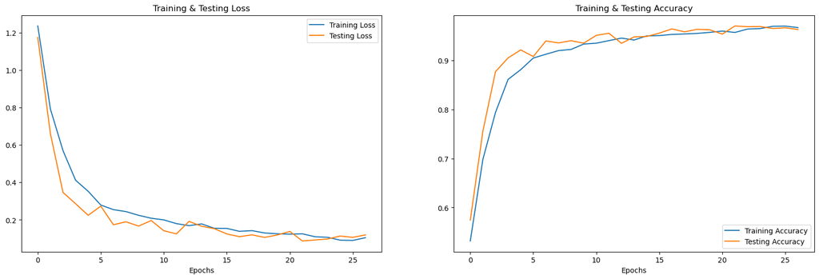

```python
# Evaluate the model on the test data and print the accuracy
print("Accuracy of our model on test data:", LSTM_model.evaluate(x_test, y_test)[1] * 100, "%")

# Create a list of epochs for x-axis representation
epochs = range(len(history.history['loss']))


# Create subplots for loss and accuracy
fig, ax = plt.subplots(1, 2)  # 1 row, 2 columns of plots

# Extract training and validation metrics from the history object
train_acc = history.history['accuracy']       # Training accuracy for each epoch
train_loss = history.history['loss']           # Training loss for each epoch
test_acc = history.history['val_accuracy']     # Validation accuracy for each epoch
test_loss = history.history['val_loss']        # Validation loss for each epoch

# Set the size of the figure
fig.set_size_inches(20, 6)

# Plot the training and testing loss
ax[0].plot(epochs, train_loss, label='Training Loss')  # Plot training loss
ax[0].plot(epochs, test_loss, label='Testing Loss')    # Plot testing loss
ax[0].set_title('Training & Testing Loss')              # Title for the loss plot
ax[0].legend()                                         # Add a legend to the plot
ax[0].set_xlabel("Epochs")                            # Label for x-axis

# Plot the training and testing accuracy
ax[1].plot(epochs, train_acc, label='Training Accuracy')  # Plot training accuracy
ax[1].plot(epochs, test_acc, label='Testing Accuracy')    # Plot testing accuracy
ax[1].set_title('Training & Testing Accuracy')             # Title for the accuracy plot
ax[1].legend()                                           # Add a legend to the plot
ax[1].set_xlabel("Epochs")                              # Label for x-axis

# Display the plots
plt.show()
```

### **Predicting on test data**

```python
# Predicting on test data
# Use the trained model to generate predictions for the test dataset
pred_test = LSTM_model.predict(x_test)

# Convert probabilities to class labels
y_pred = np.argmax(pred_test, axis=1)

# Get the number of classes from the encoder
num_classes = encoder.categories_[0].size  # Number of classes based on the fitted encoder

# Convert predictions to one-hot encoding for inverse transformation
y_pred_one_hot = np.zeros((y_pred.size, num_classes))  # Use num_classes instead of encoder.n_classes_
y_pred_one_hot[np.arange(y_pred.size), y_pred] = 1

# Inverse transform the predicted labels back to their original form
y_pred_labels = encoder.inverse_transform(y_pred_one_hot)

# Inverse transform the true labels from y_test back to their original form
y_test_labels = np.argmax(y_test, axis=1)  # Convert one-hot encoded y_test back to class labels

# Convert true labels to one-hot encoding for inverse transformation
y_test_one_hot = np.zeros((y_test_labels.size, num_classes))
y_test_one_hot[np.arange(y_test_labels.size), y_test_labels] = 1
y_test_labels_original = encoder.inverse_transform(y_test_one_hot)
```

```
110/110 ━━━━━━━━━━━━━━━━━━━━ 2s 14ms/step
```

## **Create a DataFrame to store predicted and actual labels**

```python
# Create a DataFrame to store predicted and actual labels
df = pd.DataFrame(columns=['Predicted Labels', 'Actual Labels'])

# Convert predicted labels to one-hot encoding before inverse transformation
predicted_one_hot = np.zeros((y_pred.size, encoder.categories_[0].size))
predicted_one_hot[np.arange(y_pred.size), y_pred] = 1

# Inverse transform the predicted labels to get the actual string labels
predicted_labels = encoder.inverse_transform(predicted_one_hot)

# Flatten the result to a 1D array
df['Predicted Labels'] = predicted_labels.flatten()

# Convert one-hot encoded y_test back to class labels if necessary
if len(y_test.shape) > 1:  # If y_test is one-hot encoded
    y_test_labels = np.argmax(y_test, axis=1)  # Get the class indices
else:
    y_test_labels = y_test.flatten()  # If already in the correct shape

# Create a one-hot encoded array for the actual labels
actual_one_hot = np.zeros((y_test_labels.size, encoder.categories_[0].size))
actual_one_hot[np.arange(y_test_labels.size), y_test_labels] = 1

# Inverse transform the actual labels to get the actual string labels
actual_labels = encoder.inverse_transform(actual_one_hot)

# Flatten the result to a 1D array
df['Actual Labels'] = actual_labels.flatten()

# Display the first 10 rows of the DataFrame to inspect the predicted and actual labels
df.sample(10)
```

|  | Predicted Labels | Actual Labels |
| --- | --- | --- |
| 64 | angry | angry |
| 190 | angry | angry |
| 1527 | fear | fear |
| 429 | neutral | neutral |
| 2638 | disgust | disgust |
| 2988 | happy | happy |
| 2188 | neutral | neutral |
| 2078 | sad | sad |
| 2477 | sad | sad |
| 3392 | disgust | disgust |

### **Compute the confusion matrix using the actual and predicted labels**

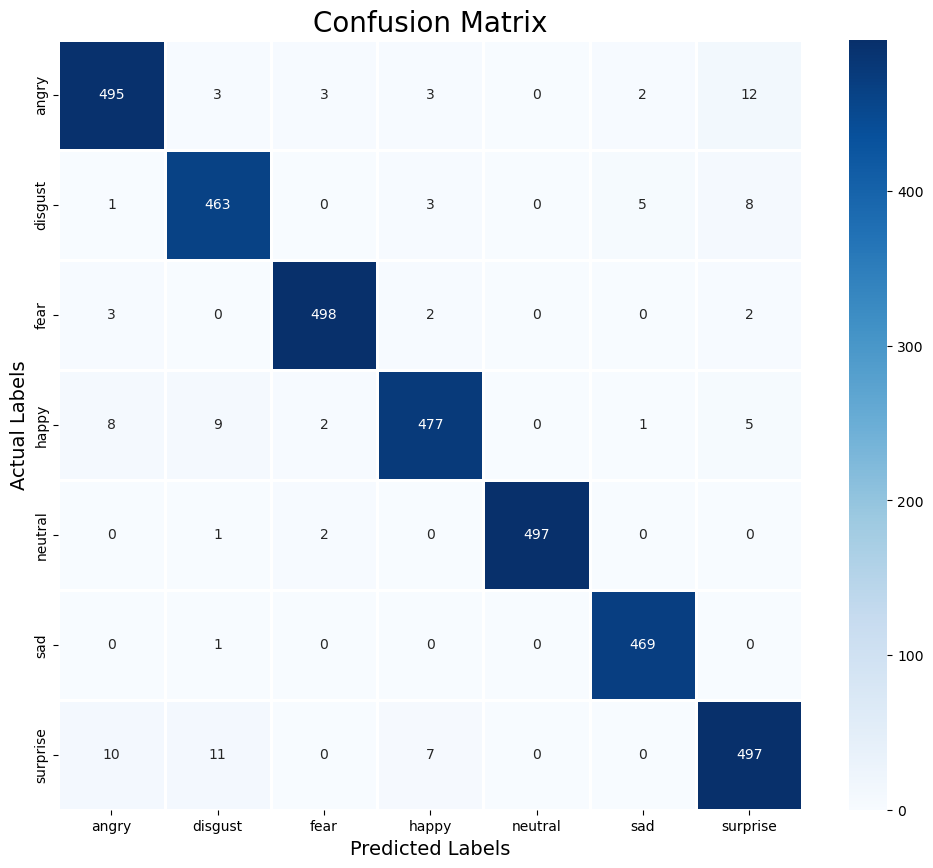

```python
# Assuming df is your DataFrame with 'Predicted Labels' and 'Actual Labels'

# Create confusion matrix using the actual and predicted labels
# Use the first element of encoder.categories_ to get the class names
cm = confusion_matrix(df['Actual Labels'], df['Predicted Labels'], labels=encoder.categories_[0])

# Set the figure size for the plot
plt.figure(figsize=(12, 10))

# Create a DataFrame from the confusion matrix for better visualization
cm_df = pd.DataFrame(cm, index=encoder.categories_[0], columns=encoder.categories_[0])

# Create a heatmap from the confusion matrix DataFrame
sns.heatmap(cm_df, linecolor='white', cmap='Blues', linewidth=1, annot=True, fmt='d')

# Add title and labels to the plot
plt.title('Confusion Matrix', size=20)
plt.xlabel('Predicted Labels', size=14)
plt.ylabel('Actual Labels', size=14)

# Display the plot
plt.show()
```

```python
from sklearn.metrics import classification_report  # Import classification_report
```

```python
# Convert y_test to class indices if it is one-hot encoded
if len(y_test.shape) > 1:  # Check if y_test is one-hot encoded
    y_test_labels = np.argmax(y_test, axis=1)  # Convert to class indices
else:
    y_test_labels = y_test.flatten()  # If already in the correct shape

# Now both y_test_labels and y_pred should be in the same format
print(classification_report(y_test_labels, y_pred))
```

```
              precision    recall  f1-score   support

           0       0.96      0.96      0.96       518
           1       0.95      0.96      0.96       480
           2       0.99      0.99      0.99       505
           3       0.97      0.95      0.96       502
           4       1.00      0.99      1.00       500
           5       0.98      1.00      0.99       470
           6       0.95      0.95      0.95       525

    accuracy                           0.97      3500
   macro avg       0.97      0.97      0.97      3500
weighted avg       0.97      0.97      0.97      3500
```

```python
# Decode integer indices to actual emotion names
predicted_emotions = encoder.categories_[0][y_pred]
true_emotions = encoder.categories_[0][y_test_labels]

# Show classification report with labels
print(classification_report(true_emotions, predicted_emotions))
```

```
              precision    recall  f1-score   support

       angry       0.96      0.96      0.96       518
     disgust       0.95      0.96      0.96       480
        fear       0.99      0.99      0.99       505
       happy       0.97      0.95      0.96       502
     neutral       1.00      0.99      1.00       500
         sad       0.98      1.00      0.99       470
    surprise       0.95      0.95      0.95       525

    accuracy                           0.97      3500
   macro avg       0.97      0.97      0.97      3500
weighted avg       0.97      0.97      0.97      3500
```